# Reproducible Pitch Presentation for Week4 Project

RYH@HK  
22Nov2020

### Brief Introduction of the Shiny Application

Value-at-Risk (VaR) is a widely used indicator to measure market risk. It measures how much investment might lost within a given period of time, under probability p. For example, if a daily 99% VaR of a bank is 1 million, it means the bank will lose at most 1 million, with 99% probability, within one day.

This application calculates daily Value-at-Risk (VaR) of three indexes: S&P 500 in US market, Hang Seng Index in Hong Kong market, and Nikkei225 Index in Japan market.

- 1) Users can choose the confidence level in the slider;
- 2) Users Select the start and end days to estimate the daily return volatility, the min and max date are 2018-01-01 and 2020-06-30;
- 3) Assumes the portfolio investment is 1 millioni USD. The VaR of three portfolios will be displayed at the right.

### Data Preprocessing

```r
# the raw data is downloaded from yahoo.finance
  data_raw <- read.csv("Wk4_data.csv", header = TRUE)
  data_raw$Datenew <- as.Date(data_raw$Date, format = "%m/%d/%Y")
# Use the dateRangeInput widget to choose start and end date
# Use the SliderInput to choose confidence level
# For example, the start and end date is 2019-01-01 and 2019-12-31,
# The confidence level is 0.95 and the portfolio investment is 1 million USD.
  data_sub <- data_raw[(data_raw$Datenew >= "2019-01-01" &
                          data_raw$Datenew <= "2019-12-31"), ]
```

### Calculate daily volatility and VaR

```r
# calculate daily volatility of the chosen date range
  vol_sp500 <- sd(data_sub[, "SP500"])
  vol_hsi <- sd(data_sub[, "HKHSI"])
  vol_nikkei <- sd(data_sub[, "Nikkei225"])
# Calculate daily VaR
  print(paste("Daily VaR for 1 million USD S&P500 portfolio:",
              1000000*vol_sp500*qnorm(0.95)))
  print(paste("Daily VaR for 1 million USD Hang Seng Index portfolio:",
              1000000*vol_hsi*qnorm(0.95)))
  print(paste("Daily VaR for 1 million USD Nikkei225 portfolio:",
              1000000*vol_nikkei*qnorm(0.95)))
```

```
[1] "Daily VaR for 1 million USD S&P500 portfolio: 12672"
```

```
[1] "Daily VaR for 1 million USD Hang Seng Index portfolio: 16217"
```

```
[1] "Daily VaR for 1 million USD Nikkei225 portfolio: 14527"
```

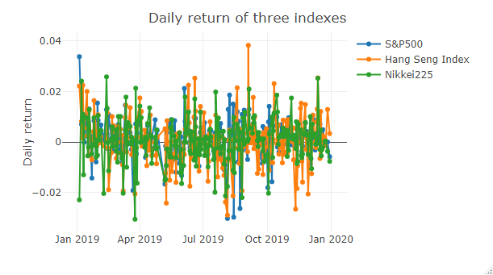